# Kākā individual-level SSFs

Author

Scott Forrest

Here we are fitting step selection functions to the GPS data of individual kākā from Orokonui Ecosanctuary. We will fit a separate SSF for each individual, and then compare the coefficients to see if there are any consistent patterns relating to factors such as age or sex in habitat selection.

# Load Packages

```r
library(tidyverse)
packages <- c("amt", "jtools", "patchwork")
walk(packages, require, character.only = T)
```

# Import data

We import data that is output by the `data_prep` script. This dataset should be ready to use in SSF models, although we will label the habitat categories for easier interpretation.

```r
data_ssf <- read_csv("outputs/data_SSF_ready_2024-03-24.csv")
data_ssf$habsF <- factor(data_ssf$habs, labels = c("Kanuka", "Native Forest", "Exotic Conifers", "Exotic Hardwoods", "Agriculture", "Suburban", "Other"))

head(data_ssf)
```

```
# A tibble: 6 × 37
     id      x1_      x2_      y1_      y2_    sl_    ta_ t1_
  <dbl>    <dbl>    <dbl>    <dbl>    <dbl>  <dbl>  <dbl> <dttm>
1 45505 1413117. 1413222. 4931685. 4932357. 681.   -2.71  2020-09-23 04:00:08
2 45505 1413117. 1413095. 4931685. 4931664.  30.4  -0.200 2020-09-23 04:00:08
3 45505 1413117. 1413119. 4931685. 4931689.   4.85 -3.00  2020-09-23 04:00:08
4 45505 1413117. 1413341. 4931685. 4931472. 309.    1.40  2020-09-23 04:00:08
5 45505 1413117. 1413152. 4931685. 4932220. 536.   -2.62  2020-09-23 04:00:08
6 45505 1413117. 1413121. 4931685. 4931687.   4.67  2.55  2020-09-23 04:00:08
# ℹ 29 more variables: t2_ <dttm>, dt_ <dbl>, case_ <lgl>, step_id_ <dbl>,
#   habs <dbl>, scrub <dbl>, native_forest <dbl>, exotic_conifers <dbl>,
#   exotic_hardwoods <dbl>, agriculture <dbl>, suburban <dbl>, other <dbl>,
#   water <dbl>, y <dbl>, cos_ta_ <dbl>, log_sl_ <dbl>, idf <dbl>,
#   id_num <dbl>, step_id <chr>, id1 <dbl>, id2 <dbl>, id3 <dbl>, id4 <dbl>,
#   id5 <dbl>, id6 <dbl>, id7 <dbl>, id8 <dbl>, id9 <dbl>, habsF <fct>
```

Plot the distribution of used and available points within each habitat type. The code for this function comes from Fieberg et al. (2021).

```r
gg_tag <- function (gg_tag) {

  id_values <- unique(gg_tag$id)

  gg_tag %>%
    dplyr::group_by(case_, habsF) %>%
    dplyr::summarise(n = n()) %>%
    dplyr:: mutate(prop = n / sum(n),
                   label = paste0(round(prop * 100, 1), "%")) %>%
    ggplot(aes(habsF, prop, fill = case_, group=case_,label = label)) +
    geom_col(position = position_dodge2()) +
    geom_text(size = 4, vjust = -0.25, position = position_dodge(width = 1)) +
    labs(x = "Habitat Type", y = "Proportion", fill = "case_")+
    scale_fill_brewer(palette = "Paired", name="",
                      breaks=c("FALSE", "TRUE"),
                      labels=c("Available", "Used")) +
    ggtitle("Used and Available Points Landcover Type",
            subtitle = paste("ID", c(id_values), collapse = ", ")) +
    theme_classic() +
    theme(axis.text.x = element_text(margin = margin(t = 10, b = 15), angle = 0),
          legend.position = c(0.9, 0.9))
}
```

We can look at the distribution of used and available points for all individuals, or each individual separately. These plots provide some indication of how much a kākā used certain landcover types compared to what was available, which is typically reflected in the SSF coefficients.

**All IDs**

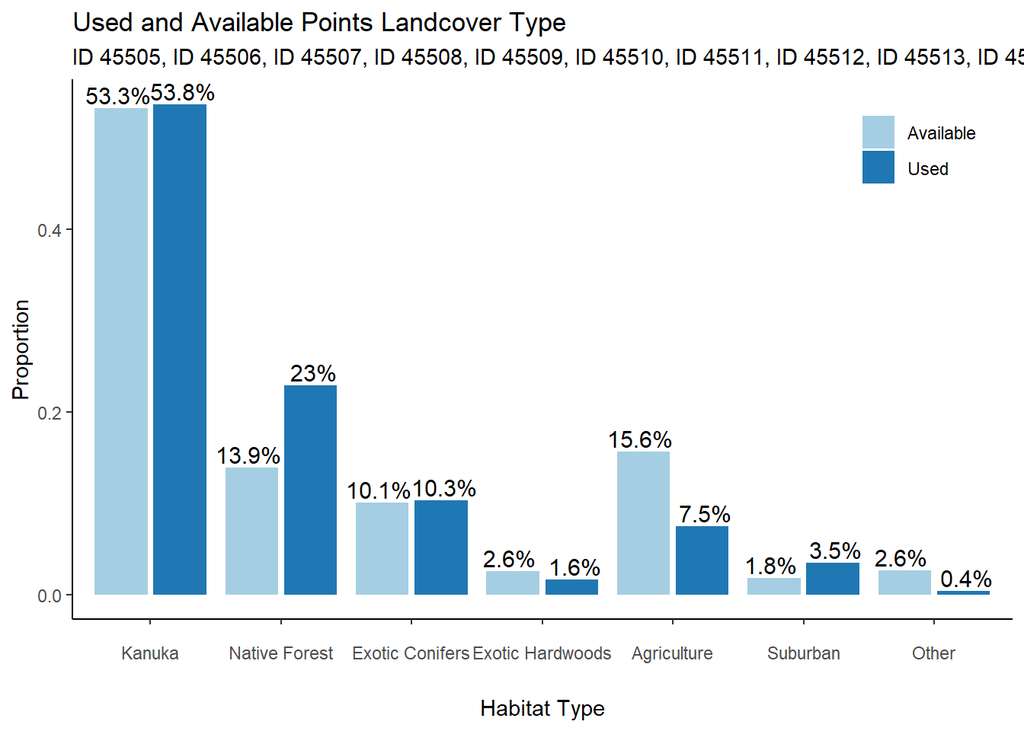

```r
gg_tag(data_ssf)
```

**ID 45505**

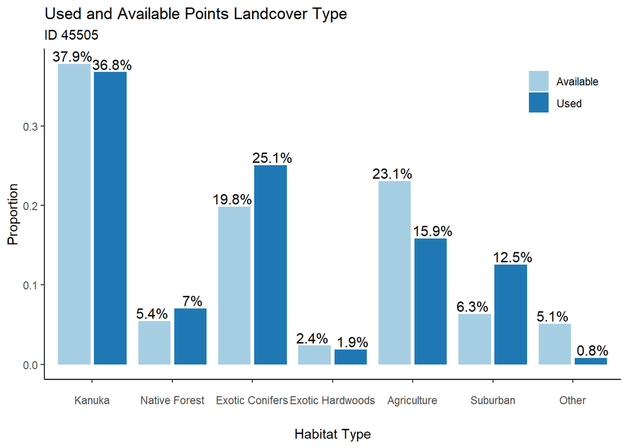

```r
data_ssf %>% filter(id == 45505) %>% gg_tag()
```

**ID 45506**

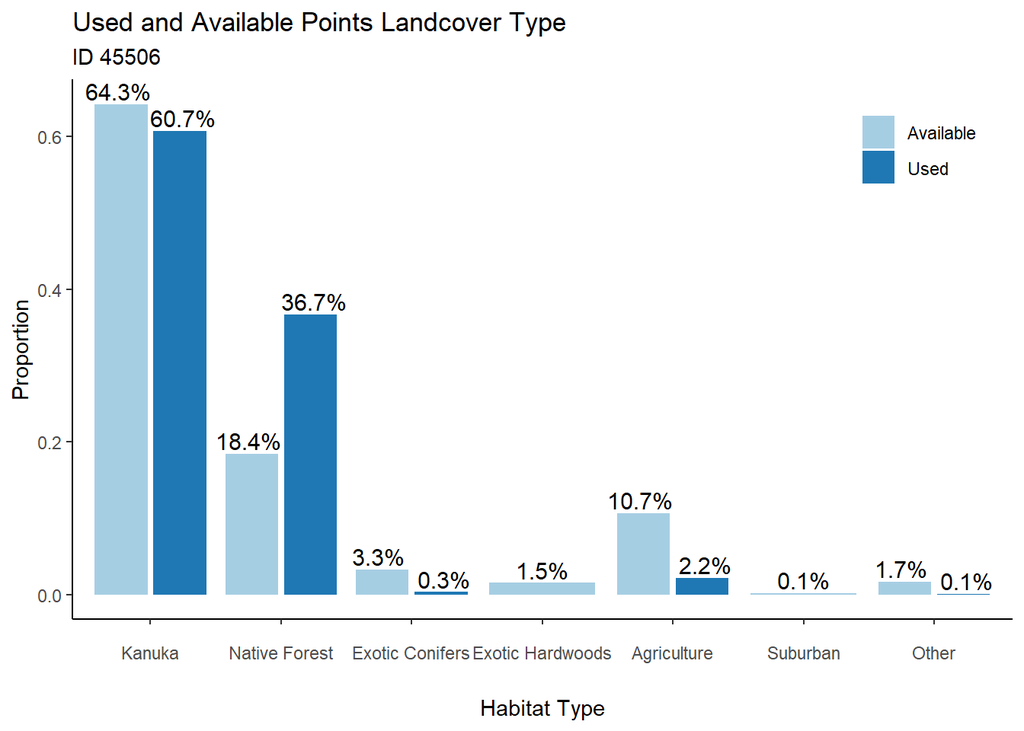

```r
data_ssf %>% filter(id == 45506) %>% gg_tag()
```

**ID 45507**

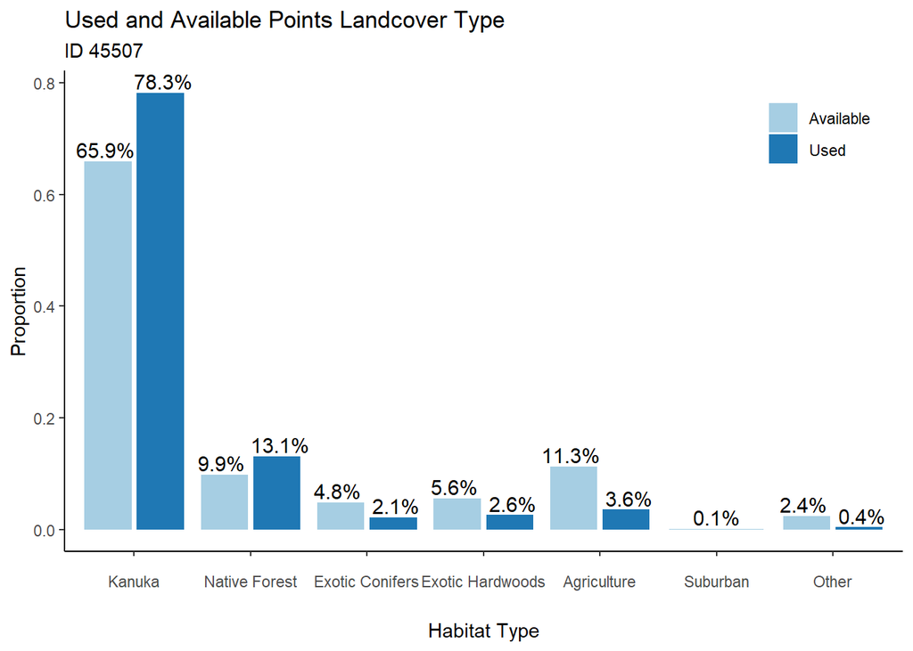

```r
data_ssf %>% filter(id == 45507) %>% gg_tag()
```

**ID 45508**

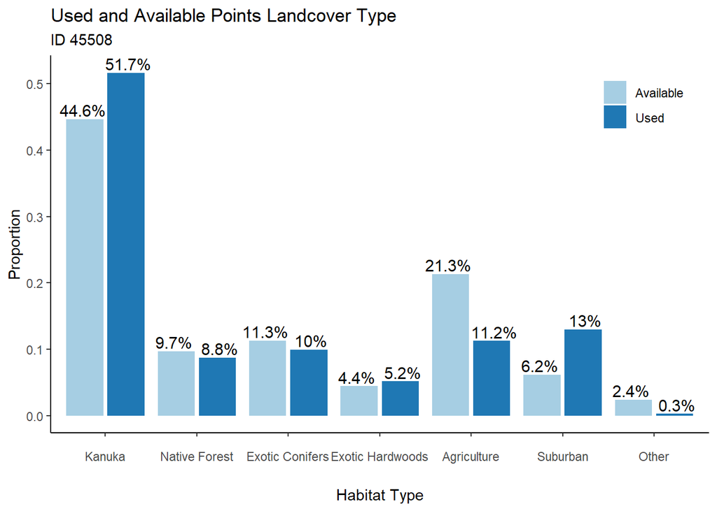

```r
data_ssf %>% filter(id == 45508) %>% gg_tag()
```

**ID 45509**

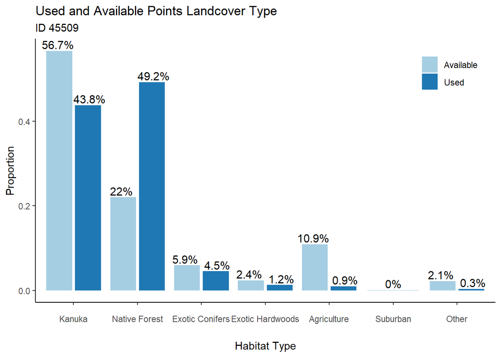

```r
data_ssf %>% filter(id == 45509) %>% gg_tag()
```

**ID 45510**

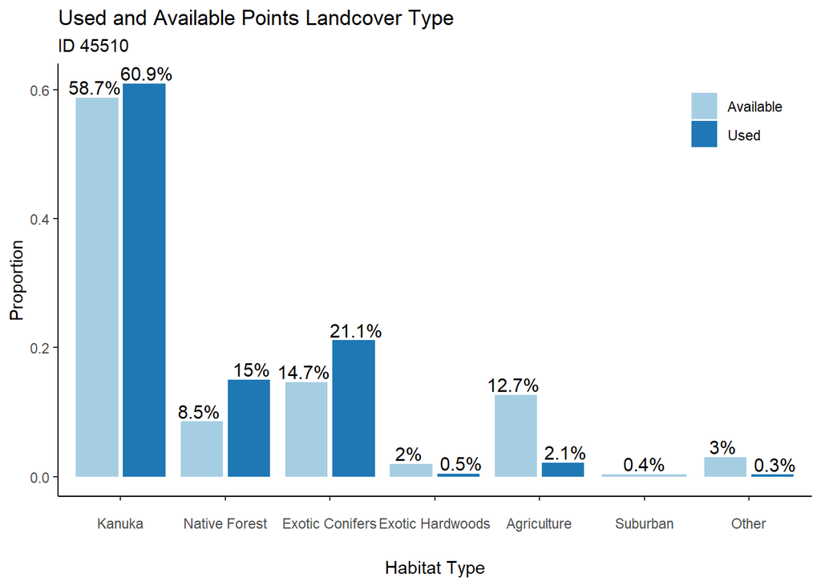

```r
data_ssf %>% filter(id == 45510) %>% gg_tag()
```

**ID 45511**

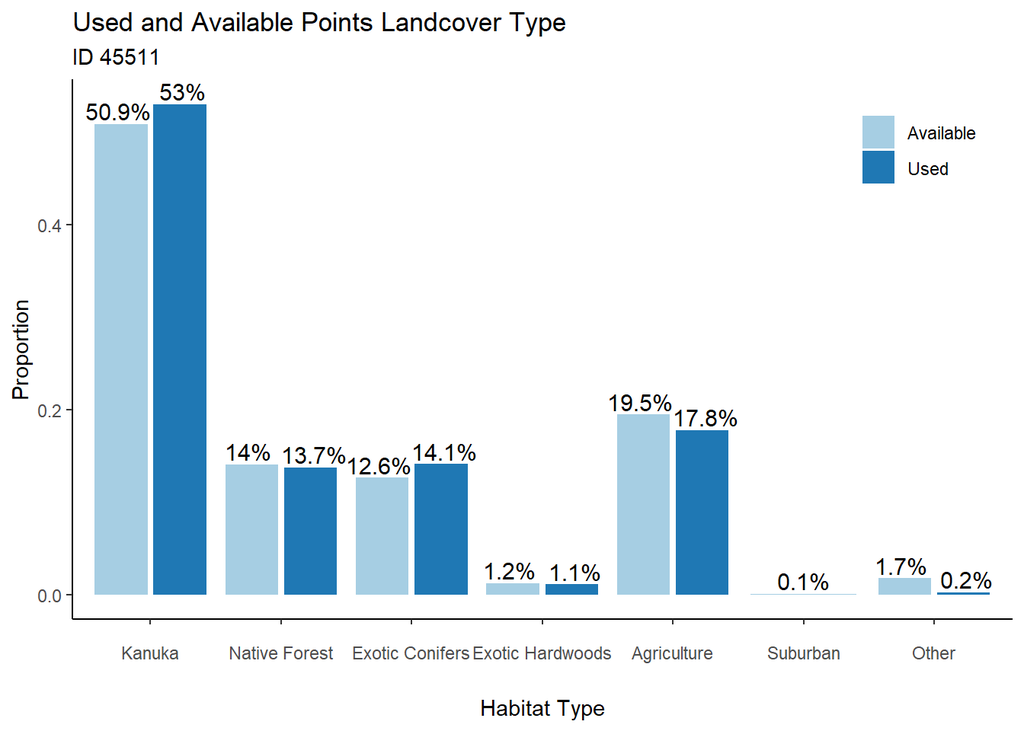

```r
data_ssf %>% filter(id == 45511) %>% gg_tag()
```

**ID 45512**

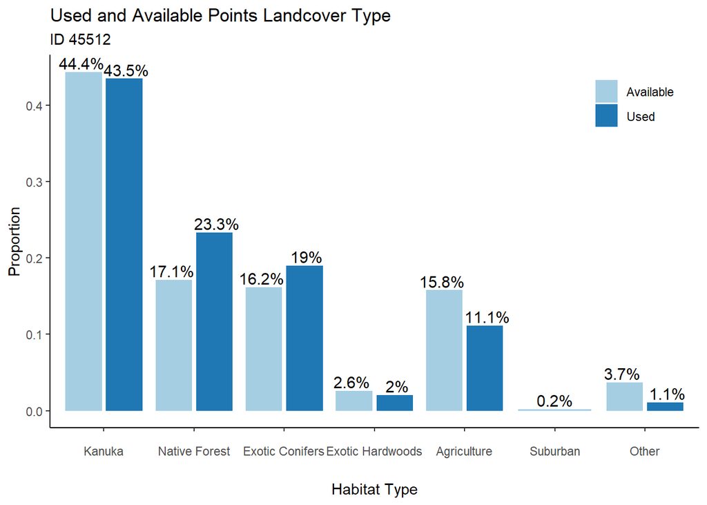

```r
data_ssf %>% filter(id == 45512) %>% gg_tag()
```

**ID 45513**

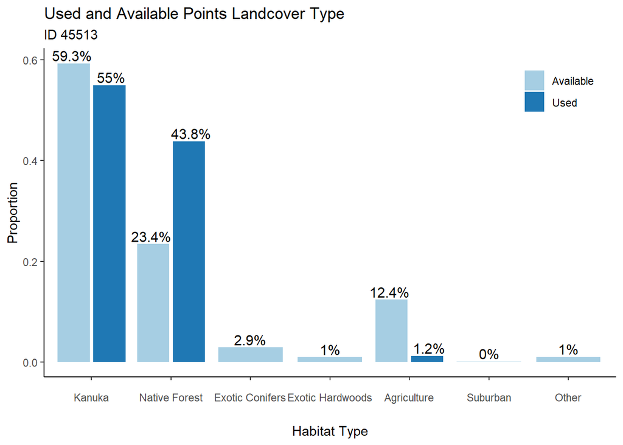

```r
data_ssf %>% filter(id == 45513) %>% gg_tag()
```

**ID 45514**

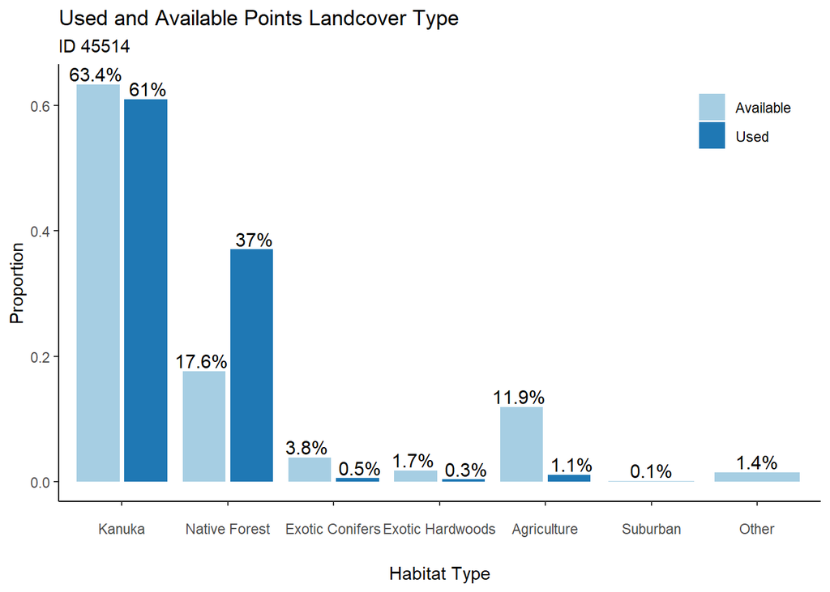

```r
data_ssf %>% filter(id == 45514) %>% gg_tag()
```

# Fit SSF models

We’ll nest the data to `map` the SSF model fitting over each individual.

```r
data_ssf_nested <- data_ssf %>% group_by(id) %>% nest()
```

## Fit the models

There are some warnings as the suburban habitat category wasn’t visited by all individuals, so the standard errors for those individuals are really large, but the coefficients appear to have been estimated correctly.

```r
data_ssf_nested <- data_ssf_nested %>%
  mutate(ssf = lapply(data, function(x) {
    x %>% fit_issf(case_ ~ habsF + sl_ + log_sl_ + cos_ta_ + strata(step_id_))
  } ))
```

```
Warning: There were 8 warnings in `mutate()`.
The first warning was:
ℹ In argument: `ssf = lapply(...)`.
ℹ In group 2: `id = 45506`.
Caused by warning in `coxexact.fit()`:
! Loglik converged before variable  3,5 ; beta may be infinite.
ℹ Run `dplyr::last_dplyr_warnings()` to see the 7 remaining warnings.
```

## Check model outputs

**ID 45505**

```r
data_ssf_nested$ssf[1]
```

```
[[1]]
$model
Call:
survival::clogit(formula, data = data, ...)

                            coef  exp(coef)   se(coef)       z        p
habsFNative Forest     2.008e-01  1.222e+00  1.188e-01   1.690 0.090936
habsFExotic Conifers   3.885e-01  1.475e+00  8.398e-02   4.626 3.73e-06
habsFExotic Hardwoods -3.981e-01  6.716e-01  2.261e-01  -1.761 0.078275
habsFAgriculture      -5.181e-01  5.957e-01  9.267e-02  -5.590 2.27e-08
habsFSuburban          9.416e-01  2.564e+00  1.091e-01   8.631  < 2e-16
habsFOther            -1.856e+00  1.563e-01  2.988e-01  -6.211 5.27e-10
sl_                    2.682e-04  1.000e+00  5.448e-05   4.922 8.57e-07
log_sl_               -6.900e-02  9.333e-01  2.064e-02  -3.343 0.000828
cos_ta_               -4.384e-01  6.451e-01  4.075e-02 -10.758  < 2e-16

Likelihood ratio test=388.1  on 9 df, p=< 2.2e-16
n= 16071, number of events= 1451

$sl_
NULL

$ta_
NULL

$more
NULL

attr(,"class")
[1] "fit_clogit" "list"
```

**ID 45506**

```r
data_ssf_nested$ssf[2]
```

```
[[1]]
$model
Call:
survival::clogit(formula, data = data, ...)

                            coef  exp(coef)   se(coef)       z       p
habsFNative Forest     8.118e-01  2.252e+00  7.969e-02  10.187 < 2e-16
habsFExotic Conifers  -1.866e+00  1.547e-01  5.961e-01  -3.131 0.00174
habsFExotic Hardwoods -1.666e+01  5.802e-08  1.522e+03  -0.011 0.99127
habsFAgriculture      -1.062e+00  3.457e-01  2.531e-01  -4.197 2.7e-05
habsFSuburban         -1.472e+01  4.032e-07  4.973e+03  -0.003 0.99764
habsFOther            -2.308e+00  9.947e-02  1.009e+00  -2.288 0.02213
sl_                   -1.905e-03  9.981e-01  1.918e-04  -9.933 < 2e-16
log_sl_                4.920e-01  1.636e+00  5.023e-02   9.795 < 2e-16
cos_ta_               -6.420e-01  5.262e-01  5.453e-02 -11.774 < 2e-16

Likelihood ratio test=632  on 9 df, p=< 2.2e-16
n= 10164, number of events= 924

$sl_
NULL

$ta_
NULL

$more
NULL

attr(,"class")
[1] "fit_clogit" "list"
```

**ID 45507**

```r
data_ssf_nested$ssf[3]
```

```
[[1]]
$model
Call:
survival::clogit(formula, data = data, ...)

                            coef  exp(coef)   se(coef)       z        p
habsFNative Forest     2.011e-01  1.223e+00  1.025e-01   1.962   0.0498
habsFExotic Conifers  -1.102e+00  3.323e-01  2.287e-01  -4.817 1.46e-06
habsFExotic Hardwoods -1.057e+00  3.476e-01  2.062e-01  -5.125 2.98e-07
habsFAgriculture      -1.483e+00  2.270e-01  1.818e-01  -8.155 3.49e-16
habsFSuburban         -1.434e+01  5.930e-07  1.112e+03  -0.013   0.9897
habsFOther            -2.148e+00  1.167e-01  5.072e-01  -4.235 2.29e-05
sl_                   -2.293e-04  9.998e-01  9.933e-05  -2.308   0.0210
log_sl_                2.655e-01  1.304e+00  3.823e-02   6.945 3.77e-12
cos_ta_               -6.306e-01  5.323e-01  5.017e-02 -12.569  < 2e-16

Likelihood ratio test=448.5  on 9 df, p=< 2.2e-16
n= 11440, number of events= 1040

$sl_
NULL

$ta_
NULL

$more
NULL

attr(,"class")
[1] "fit_clogit" "list"
```

**ID 45508**

```r
data_ssf_nested$ssf[4]
```

```
[[1]]
$model
Call:
survival::clogit(formula, data = data, ...)

                            coef  exp(coef)   se(coef)      z        p
habsFNative Forest    -2.595e-01  7.714e-01  1.164e-01 -2.230  0.02574
habsFExotic Conifers  -3.138e-01  7.307e-01  1.203e-01 -2.609  0.00908
habsFExotic Hardwoods  2.302e-02  1.023e+00  1.570e-01  0.147  0.88340
habsFAgriculture      -9.252e-01  3.964e-01  1.065e-01 -8.690  < 2e-16
habsFSuburban          7.857e-01  2.194e+00  1.244e-01  6.316 2.68e-10
habsFOther            -2.687e+00  6.809e-02  5.862e-01 -4.584 4.57e-06
sl_                    4.951e-04  1.000e+00  5.388e-05  9.190  < 2e-16
log_sl_               -6.221e-02  9.397e-01  2.345e-02 -2.653  0.00798
cos_ta_               -3.550e-01  7.012e-01  4.571e-02 -7.766 8.11e-15

Likelihood ratio test=357.9  on 9 df, p=< 2.2e-16
n= 12844, number of events= 1165

$sl_
NULL

$ta_
NULL

$more
NULL

attr(,"class")
[1] "fit_clogit" "list"
```

**ID 45509**

```r
data_ssf_nested$ssf[5]
```

```
[[1]]
$model
Call:
survival::clogit(formula, data = data, ...)

                            coef  exp(coef)   se(coef)      z        p
habsFNative Forest     1.165e+00  3.205e+00  9.694e-02 12.013  < 2e-16
habsFExotic Conifers  -3.072e-01  7.355e-01  2.143e-01 -1.433  0.15177
habsFExotic Hardwoods -6.362e-01  5.293e-01  3.801e-01 -1.674  0.09418
habsFAgriculture      -2.662e+00  6.984e-02  4.235e-01 -6.284 3.30e-10
habsFSuburban         -1.364e+01  1.187e-06  1.317e+03 -0.010  0.99173
habsFOther            -2.206e+00  1.102e-01  7.253e-01 -3.041  0.00236
sl_                    6.320e-04  1.001e+00  8.601e-05  7.348 2.01e-13
log_sl_               -7.188e-02  9.306e-01  3.429e-02 -2.096  0.03606
cos_ta_               -4.531e-01  6.357e-01  6.350e-02 -7.136 9.64e-13

Likelihood ratio test=422.6  on 9 df, p=< 2.2e-16
n= 7062, number of events= 642

$sl_
NULL

$ta_
NULL

$more
NULL

attr(,"class")
[1] "fit_clogit" "list"
```

**ID 45510**

```r
data_ssf_nested$ssf[6]
```

```
[[1]]
$model
Call:
survival::clogit(formula, data = data, ...)

                            coef  exp(coef)   se(coef)      z        p
habsFNative Forest     6.921e-01  1.998e+00  1.389e-01  4.982 6.30e-07
habsFExotic Conifers   3.140e-01  1.369e+00  1.093e-01  2.872 0.004080
habsFExotic Hardwoods -1.530e+00  2.165e-01  5.926e-01 -2.583 0.009807
habsFAgriculture      -1.864e+00  1.550e-01  2.839e-01 -6.568 5.11e-11
habsFSuburban         -1.530e+01  2.277e-07  1.313e+03 -0.012 0.990706
habsFOther            -2.348e+00  9.552e-02  7.137e-01 -3.291 0.000999
sl_                   -1.290e-04  9.999e-01  1.202e-04 -1.073 0.283255
log_sl_                8.393e-02  1.088e+00  3.994e-02  2.102 0.035590
cos_ta_               -5.001e-01  6.064e-01  6.083e-02 -8.222  < 2e-16

Likelihood ratio test=249.8  on 9 df, p=< 2.2e-16
n= 7204, number of events= 653

$sl_
NULL

$ta_
NULL

$more
NULL

attr(,"class")
[1] "fit_clogit" "list"
```

**ID 45511**

```r
data_ssf_nested$ssf[7]
```

```
[[1]]
$model
Call:
survival::clogit(formula, data = data, ...)

                            coef  exp(coef)   se(coef)       z        p
habsFNative Forest    -3.850e-02  9.622e-01  1.142e-01  -0.337  0.73595
habsFExotic Conifers   1.234e-01  1.131e+00  1.189e-01   1.038  0.29936
habsFExotic Hardwoods -1.110e-01  8.950e-01  3.600e-01  -0.308  0.75794
habsFAgriculture      -1.496e-01  8.611e-01  1.053e-01  -1.420  0.15548
habsFSuburban         -1.430e+01  6.131e-07  1.560e+03  -0.009  0.99268
habsFOther            -2.086e+00  1.242e-01  7.175e-01  -2.907  0.00365
sl_                   -1.578e-04  9.998e-01  8.699e-05  -1.815  0.06960
log_sl_                2.431e-01  1.275e+00  4.088e-02   5.946 2.74e-09
cos_ta_               -5.598e-01  5.713e-01  5.482e-02 -10.212  < 2e-16

Likelihood ratio test=197.6  on 9 df, p=< 2.2e-16
n= 9052, number of events= 822

$sl_
NULL

$ta_
NULL

$more
NULL

attr(,"class")
[1] "fit_clogit" "list"
```

**ID 45512**

```r
data_ssf_nested$ssf[8]
```

```
[[1]]
$model
Call:
survival::clogit(formula, data = data, ...)

                            coef  exp(coef)   se(coef)      z        p
habsFNative Forest     3.768e-01  1.458e+00  9.167e-02  4.110 3.96e-05
habsFExotic Conifers   1.388e-01  1.149e+00  9.646e-02  1.439   0.1501
habsFExotic Hardwoods -1.973e-01  8.210e-01  2.418e-01 -0.816   0.4145
habsFAgriculture      -7.018e-01  4.957e-01  1.183e-01 -5.931 3.02e-09
habsFSuburban         -1.572e+01  1.494e-07  9.590e+02 -0.016   0.9869
habsFOther            -1.544e+00  2.136e-01  3.175e-01 -4.862 1.16e-06
sl_                    6.969e-04  1.001e+00  5.862e-05 11.888  < 2e-16
log_sl_                6.885e-02  1.071e+00  3.291e-02  2.092   0.0364
cos_ta_               -4.806e-01  6.184e-01  4.998e-02 -9.616  < 2e-16

Likelihood ratio test=638.3  on 9 df, p=< 2.2e-16
n= 11383, number of events= 1033

$sl_
NULL

$ta_
NULL

$more
NULL

attr(,"class")
[1] "fit_clogit" "list"
```

**ID 45513**

```r
data_ssf_nested$ssf[9]
```

```
[[1]]
$model
Call:
survival::clogit(formula, data = data, ...)

                            coef  exp(coef)   se(coef)       z        p
habsFNative Forest     5.748e-01  1.777e+00  7.688e-02   7.477 7.58e-14
habsFExotic Conifers  -1.585e+01  1.308e-07  1.658e+03  -0.010    0.992
habsFExotic Hardwoods -1.529e+01  2.298e-07  2.944e+03  -0.005    0.996
habsFAgriculture      -1.455e+00  2.333e-01  3.230e-01  -4.505 6.62e-06
habsFSuburban         -1.272e+01  2.981e-06  1.556e+04  -0.001    0.999
habsFOther            -1.553e+01  1.797e-07  2.589e+03  -0.006    0.995
sl_                   -3.774e-03  9.962e-01  3.053e-04 -12.363  < 2e-16
log_sl_                3.322e-01  1.394e+00  4.441e-02   7.481 7.39e-14
cos_ta_               -7.068e-01  4.932e-01  5.468e-02 -12.925  < 2e-16

Likelihood ratio test=867.8  on 9 df, p=< 2.2e-16
n= 10251, number of events= 931

$sl_
NULL

$ta_
NULL

$more
NULL

attr(,"class")
[1] "fit_clogit" "list"
```

**ID 45514**

```r
data_ssf_nested$ssf[10]
```

```
[[1]]
$model
Call:
survival::clogit(formula, data = data, ...)

                            coef  exp(coef)   se(coef)      z        p
habsFNative Forest     7.820e-01  2.186e+00  7.757e-02 10.081  < 2e-16
habsFExotic Conifers  -1.467e+00  2.307e-01  4.811e-01 -3.049   0.0023
habsFExotic Hardwoods -1.304e+00  2.714e-01  6.293e-01 -2.072   0.0382
habsFAgriculture      -1.901e+00  1.494e-01  3.282e-01 -5.792 6.94e-09
habsFSuburban         -1.463e+01  4.418e-07  5.607e+03 -0.003   0.9979
habsFOther            -1.661e+01  6.137e-08  1.442e+03 -0.012   0.9908
sl_                   -1.439e-03  9.986e-01  1.709e-04 -8.418  < 2e-16
log_sl_                2.503e-01  1.284e+00  3.837e-02  6.521 6.96e-11
cos_ta_               -4.957e-01  6.092e-01  5.238e-02 -9.463  < 2e-16

Likelihood ratio test=574  on 9 df, p=< 2.2e-16
n= 10362, number of events= 942

$sl_
NULL

$ta_
NULL

$more
NULL

attr(,"class")
[1] "fit_clogit" "list"
```

Add additional information to the model outputs.

```r
data_ssf_nested$Sex <- c("m", "m", "m", "f", "f", "f", "f", "m", "m", "f")
data_ssf_nested$Age <- c(1, 10, 5, 1, 3, 2, 2, 3, 10, 8)
data_ssf_nested$Origin <- c("o", "o", "c", "o", "o", "o", "o", "c", "c","o")
```

# Plot the model outputs against kākā variables

## Age

Create plot of estimated coefficients for all individuals together, relative to the reference category kānuka.

```r
# pulls out all coefficients and adds to data frame with other kākā info
d2 <- data_ssf_nested %>%
  mutate(coef = map(ssf, ~ broom::tidy(.x$model))) %>%
  dplyr::select(id, Sex, coef, Age, Origin) %>%
  unnest(cols = c(coef)) %>%
  mutate(id = factor(id)) %>%
  drop_na()
# remove coefficients relating to the movement parameters and also those that are less than -5 as they are due to the suburban habitat category not being visited by all individuals
d3 <- d2 %>% filter(grepl("habs", term)) %>%
  filter(estimate > -5)

d4 <- d3 %>% dplyr::group_by(term) %>%
  dplyr::summarise(
    mean = mean(estimate),
    ymin = mean - 1.96 * sd(estimate),
    ymax = mean + 1.96 * sd(estimate)
    )

# rank the means from largest to smallest (rank() default is from smallest to largest)
rank_df <- data.frame(term = unique(d4$term), desc_order = rank(-d4$mean))
rank_df
```

```
                   term desc_order
1      habsFAgriculture          5
2  habsFExotic Conifers          3
3 habsFExotic Hardwoods          4
4    habsFNative Forest          2
5            habsFOther          6
6         habsFSuburban          1
```

```r
# add an ordering column to d3 - these will need to be changed depending on the covariates
d3$order <- ifelse(d3$term == "habsFAgriculture", 5,
       ifelse(d3$term == "habsFExotic Conifers", 3,
              ifelse(d3$term == "habsFExotic Hardwoods", 4,
                     ifelse(d3$term == "habsFNative Forest", 2,
                            ifelse(d3$term == "habsFOther", 6,
                                   ifelse(d3$term == "habsFSuburban", 1, NA))))))

# add an ordering colum to d3 using ranks
# d3$order <- rep(desc_order, times = as.vector(table(d3$term)))
d3$id <- as.factor(d3$id)
d3 <- d3[order(d3$order),]

# rank from largest to smallest (rank() default is from smallest to largest)
d4$order <- rank_df$desc_order
d4 <- d4[order(d4$order),]
d4$term <- factor(d4$term)

coefficients <- d3
coefficients$x <- 1:nrow(coefficients)
```

Create the plot

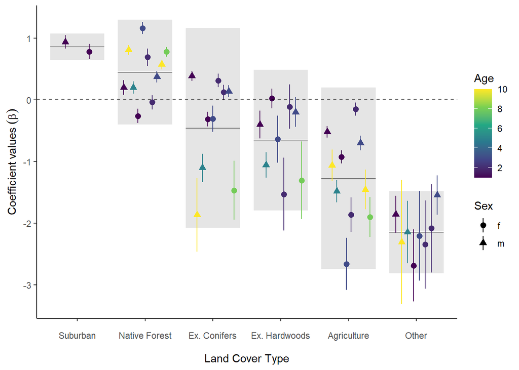

```r
ggplot(data = d3,
       aes(x = reorder(term, order), y = estimate, group = id, col = Age, pch = Sex)) +
  geom_rect(data = d4,
            aes(xmin = order - 0.4, xmax = order + 0.4, ymin = ymin, ymax = ymax),
            inherit.aes = F,
            fill = "grey90") +
  geom_segment(data = d4, aes(x = order - 0.4, xend = order + 0.4, y = mean, yend = mean),
               inherit.aes = F,
               size = 0.25) +
  geom_pointrange(aes(ymin = estimate - std.error, ymax = estimate + std.error),
                  position = position_dodge(width = 0.7), size = 0.5) +
  geom_hline(yintercept = 0, lty = 2) +
  labs(x = "Land Cover Type", y = expression(Coefficient~values~(beta))) +
  scale_colour_viridis_c("Age", breaks = seq(0,10,2)) +
  theme_classic() +
  theme(axis.text.x = element_text(margin = margin(t = 10, b = 10), angle = 0)) +
  scale_x_discrete(labels =
                     c("Suburban", "Native Forest",
                       "Ex. Conifers", "Ex. Hardwoods",
                       "Agriculture", "Other"))
```

## Sex

There doesn’t appear to be a trend for sex in any of the covariates.

```r
terms <- unique(d3$term)
```

**Suburban**

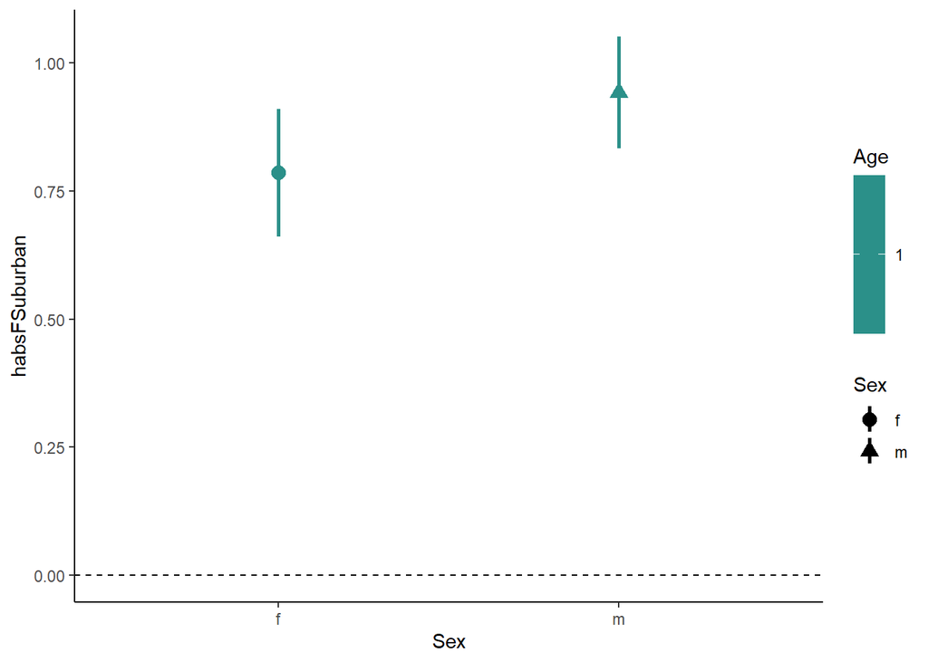

```r
ggplot() +
  geom_pointrange(data = d3 %>% filter(term == terms[1]),
                  aes(x = Sex,
                      y = estimate,
                      group = id, col = Age, pch = Sex,
                      ymin = estimate - std.error,
                      ymax = estimate + std.error),
                  position = position_dodge(width = 0.5),
                  size = 0.75,
                  linewidth = 1) +
  geom_hline(yintercept = 0, lty = 2) +
  scale_colour_viridis_c("Age", breaks = seq(0,10,2)) +
  scale_y_continuous(terms[1]) +
  theme_classic()
```

**Native forest**

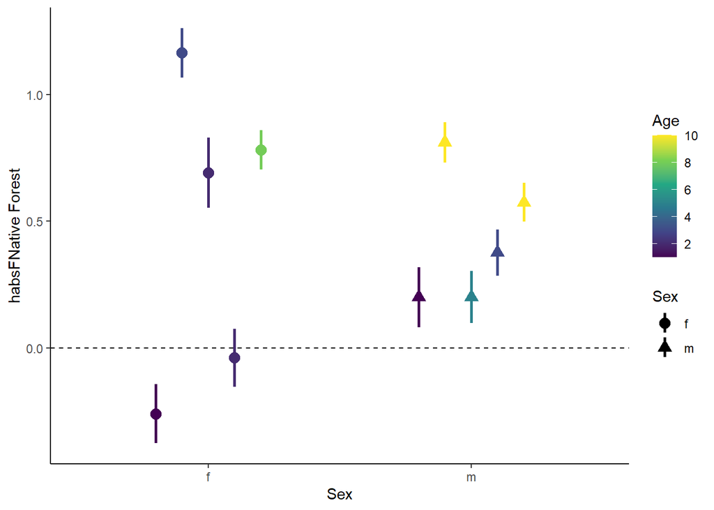

```r
ggplot() +
  geom_pointrange(data = d3 %>% filter(term == terms[2]),
                  aes(x = Sex,
                      y = estimate,
                      group = id, col = Age, pch = Sex,
                      ymin = estimate - std.error,
                      ymax = estimate + std.error),
                  position = position_dodge(width = 0.5),
                  size = 0.75,
                  linewidth = 1) +
  geom_hline(yintercept = 0, lty = 2) +
  scale_colour_viridis_c("Age", breaks = seq(0,10,2)) +
  scale_y_continuous(terms[2]) +
  theme_classic()
```

**Exotic Conifers**

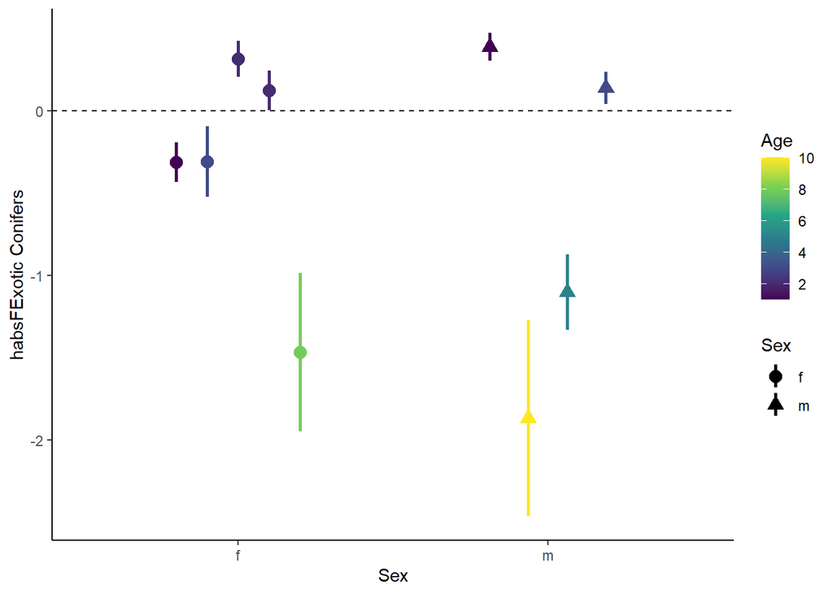

```r
ggplot() +
  geom_pointrange(data = d3 %>% filter(term == terms[3]),
                  aes(x = Sex,
                      y = estimate,
                      group = id, col = Age, pch = Sex,
                      ymin = estimate - std.error,
                      ymax = estimate + std.error),
                  position = position_dodge(width = 0.5),
                  size = 0.75,
                  linewidth = 1) +
  geom_hline(yintercept = 0, lty = 2) +
  scale_colour_viridis_c("Age", breaks = seq(0,10,2)) +
  scale_y_continuous(terms[3]) +
  theme_classic()
```

**Exotic Hardwoods**

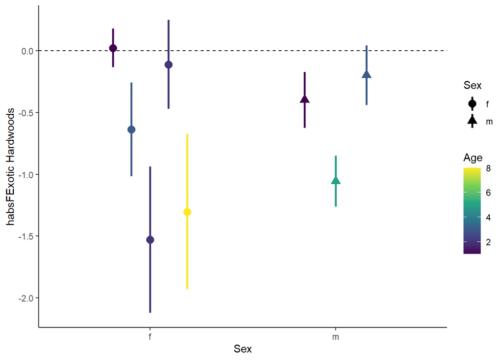

```r
ggplot() +
  geom_pointrange(data = d3 %>% filter(term == terms[4]),
                  aes(x = Sex,
                      y = estimate,
                      group = id, col = Age, pch = Sex,
                      ymin = estimate - std.error,
                      ymax = estimate + std.error),
                  position = position_dodge(width = 0.5),
                  size = 0.75,
                  linewidth = 1) +
  geom_hline(yintercept = 0, lty = 2) +
  scale_colour_viridis_c("Age", breaks = seq(0,10,2)) +
  scale_y_continuous(terms[4]) +
  theme_classic()
```

**Agriculture**

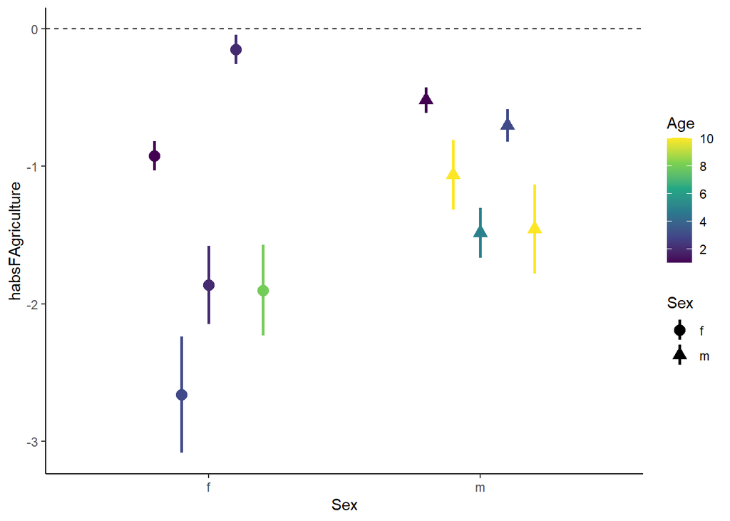

```r
ggplot() +
  geom_pointrange(data = d3 %>% filter(term == terms[5]),
                  aes(x = Sex,
                      y = estimate,
                      group = id, col = Age, pch = Sex,
                      ymin = estimate - std.error,
                      ymax = estimate + std.error),
                  position = position_dodge(width = 0.5),
                  size = 0.75,
                  linewidth = 1) +
  geom_hline(yintercept = 0, lty = 2) +
  scale_colour_viridis_c("Age", breaks = seq(0,10,2)) +
  scale_y_continuous(terms[5]) +
  theme_classic()
```

**Other**

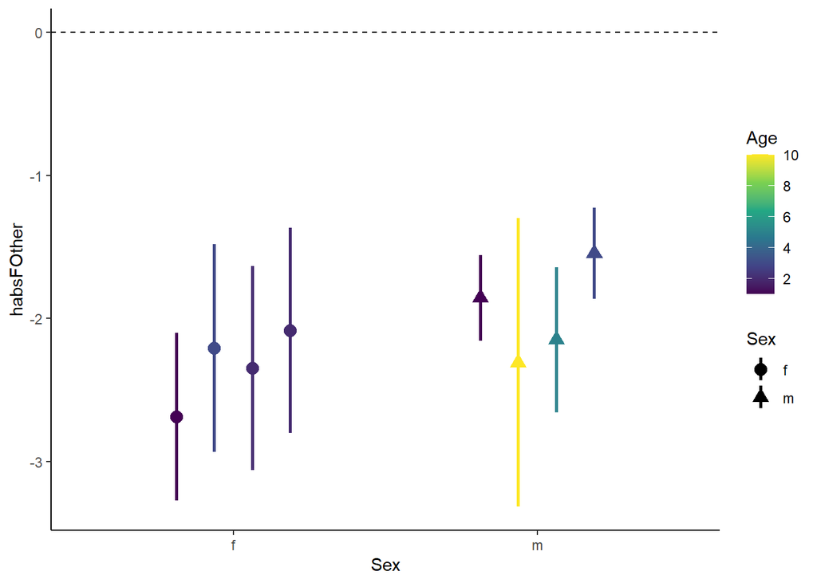

```r
ggplot() +
  geom_pointrange(data = d3 %>% filter(term == terms[6]),
                  aes(x = Sex,
                      y = estimate,
                      group = id, col = Age, pch = Sex,
                      ymin = estimate - std.error,
                      ymax = estimate + std.error),
                  position = position_dodge(width = 0.5),
                  size = 0.75,
                  linewidth = 1) +
  geom_hline(yintercept = 0, lty = 2) +
  scale_colour_viridis_c("Age", breaks = seq(0,10,2)) +
  scale_y_continuous(terms[6]) +
  theme_classic()
```

## Origin

Origin is whether the kākā was captive-raised and released into the sanctuary, or whether the kākā was hatched in an Orokonui nest. In the x-axis ‘c’ is captive and ‘o’ is Orokonui.

There also doesn’t appear to be a trend for origin in any of the covariates.

**Suburban**

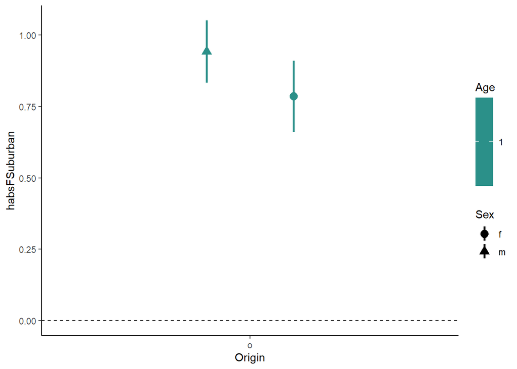

```r
ggplot() +
  geom_pointrange(data = d3 %>% filter(term == terms[1]),
                  aes(x = Origin,
                      y = estimate,
                      group = id, col = Age, pch = Sex,
                      ymin = estimate - std.error,
                      ymax = estimate + std.error),
                  position = position_dodge(width = 0.5),
                  size = 0.75,
                  linewidth = 1) +
  geom_hline(yintercept = 0, lty = 2) +
  scale_colour_viridis_c("Age", breaks = seq(0,10,2)) +
  scale_y_continuous(terms[1]) +
  theme_classic()
```

**Native forest**

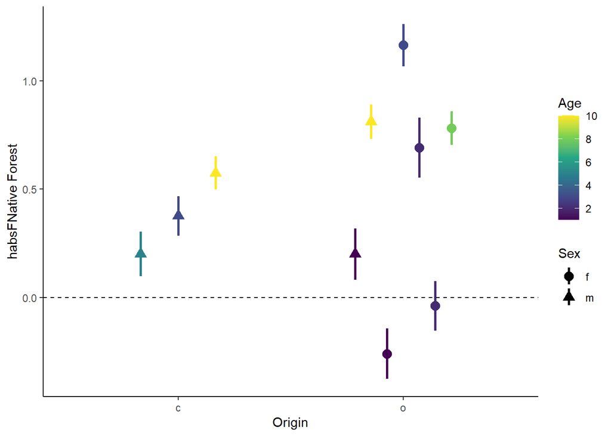

```r
ggplot() +
  geom_pointrange(data = d3 %>% filter(term == terms[2]),
                  aes(x = Origin,
                      y = estimate,
                      group = id, col = Age, pch = Sex,
                      ymin = estimate - std.error,
                      ymax = estimate + std.error),
                  position = position_dodge(width = 0.5),
                  size = 0.75,
                  linewidth = 1) +
  geom_hline(yintercept = 0, lty = 2) +
  scale_colour_viridis_c("Age", breaks = seq(0,10,2)) +
  scale_y_continuous(terms[2]) +
  theme_classic()
```

**Exotic Conifers**

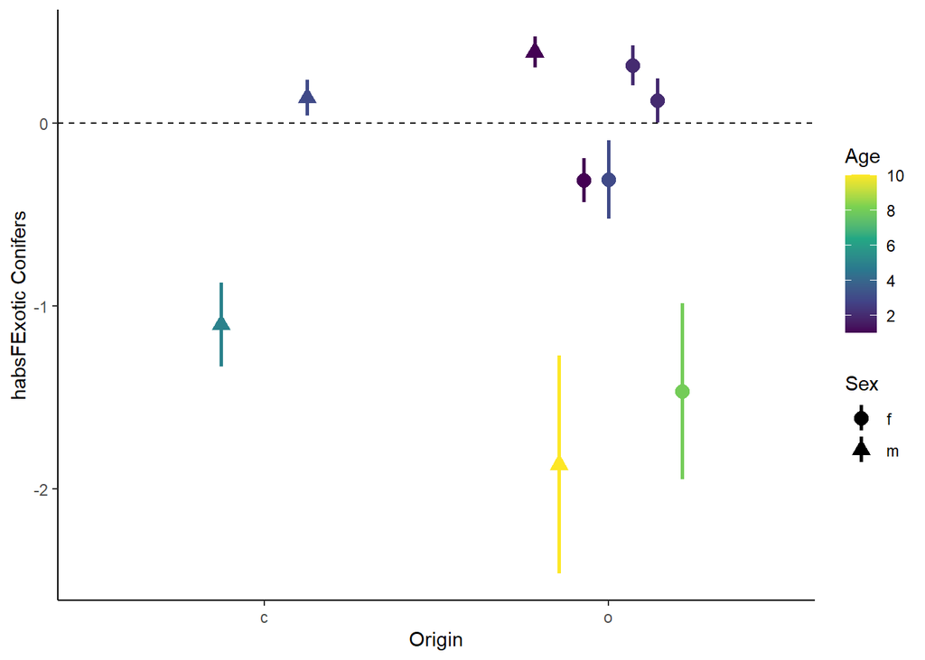

```r
ggplot() +
  geom_pointrange(data = d3 %>% filter(term == terms[3]),
                  aes(x = Origin,
                      y = estimate,
                      group = id, col = Age, pch = Sex,
                      ymin = estimate - std.error,
                      ymax = estimate + std.error),
                  position = position_dodge(width = 0.5),
                  size = 0.75,
                  linewidth = 1) +
  geom_hline(yintercept = 0, lty = 2) +
  scale_colour_viridis_c("Age", breaks = seq(0,10,2)) +
  scale_y_continuous(terms[3]) +
  theme_classic()
```

**Exotic Hardwoods**

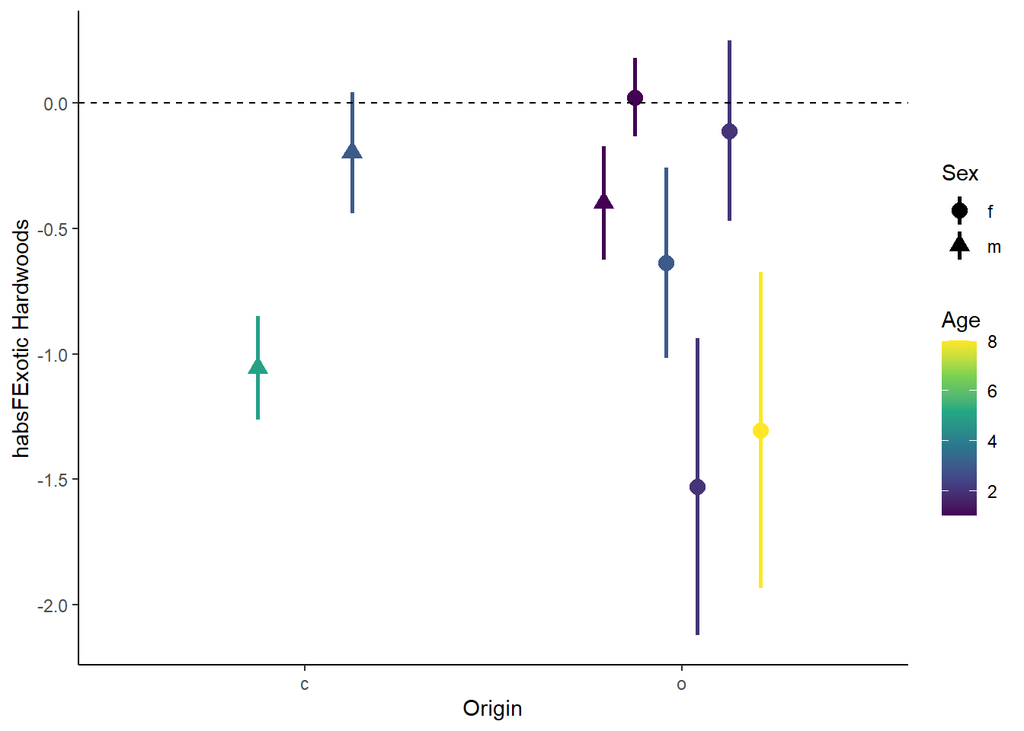

```r
ggplot() +
  geom_pointrange(data = d3 %>% filter(term == terms[4]),
                  aes(x = Origin,
                      y = estimate,
                      group = id, col = Age, pch = Sex,
                      ymin = estimate - std.error,
                      ymax = estimate + std.error),
                  position = position_dodge(width = 0.5),
                  size = 0.75,
                  linewidth = 1) +
  geom_hline(yintercept = 0, lty = 2) +
  scale_colour_viridis_c("Age", breaks = seq(0,10,2)) +
  scale_y_continuous(terms[4]) +
  theme_classic()
```

**Agriculture**

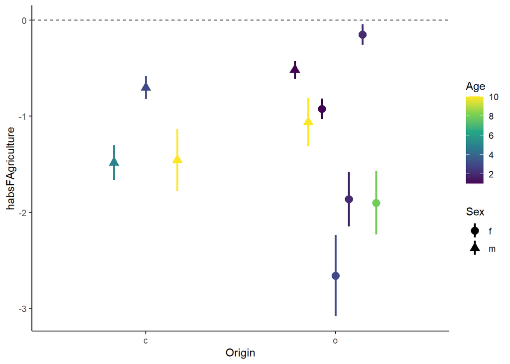

```r
ggplot() +
  geom_pointrange(data = d3 %>% filter(term == terms[5]),
                  aes(x = Origin,
                      y = estimate,
                      group = id, col = Age, pch = Sex,
                      ymin = estimate - std.error,
                      ymax = estimate + std.error),
                  position = position_dodge(width = 0.5),
                  size = 0.75,
                  linewidth = 1) +
  geom_hline(yintercept = 0, lty = 2) +
  scale_colour_viridis_c("Age", breaks = seq(0,10,2)) +
  scale_y_continuous(terms[5]) +
  theme_classic()
```

**Other**

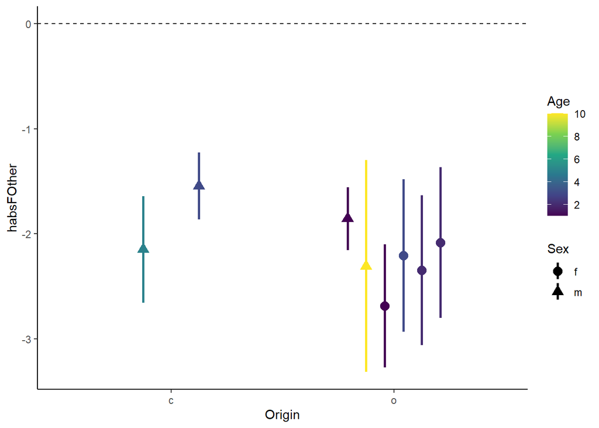

```r
ggplot() +
  geom_pointrange(data = d3 %>% filter(term == terms[6]),
                  aes(x = Origin,
                      y = estimate,
                      group = id, col = Age, pch = Sex,
                      ymin = estimate - std.error,
                      ymax = estimate + std.error),
                  position = position_dodge(width = 0.5),
                  size = 0.75,
                  linewidth = 1) +
  geom_hline(yintercept = 0, lty = 2) +
  scale_colour_viridis_c("Age", breaks = seq(0,10,2)) +
  scale_y_continuous(terms[6]) +
  theme_classic()
```

# Quantitatively assess coefficient estimates against age

Sex and origin did not appear to effect the habitat selection, however, there appeared to be an age-related effect present for some of the covariates. To quantify this we will fit some linear models.

**Native forest**

There is a positive relationship between age and the coefficient for the native forest habitat, suggesting that older individuals are using native forest more than younger individuals, although it’s not quite statistically significant.

```r
native_forest_lm <- lm(estimate ~ Age, data = coefficients, subset = (term =="habsFNative Forest"))
summary(native_forest_lm)
```

```
Call:
lm(formula = estimate ~ Age, data = coefficients, subset = (term ==
    "habsFNative Forest"))

Residuals:
     Min       1Q   Median       3Q      Max
-0.50460 -0.25885 -0.01501  0.10399  0.80204

Coefficients:
            Estimate Std. Error t value Pr(>|t|)
(Intercept)  0.18635    0.21232   0.878    0.406
Age          0.05872    0.03771   1.557    0.158

Residual standard error: 0.4035 on 8 degrees of freedom
Multiple R-squared:  0.2326,    Adjusted R-squared:  0.1367
F-statistic: 2.425 on 1 and 8 DF,  p-value: 0.158
```

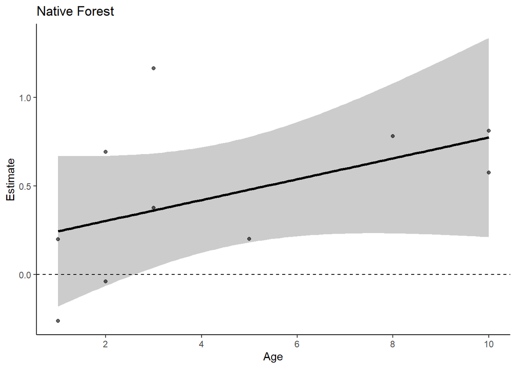

```r
# plot
nf_lm <- effect_plot(native_forest_lm, pred = Age, plot.points = T, interval = T) +
  labs(x = "Age", y = expression(paste("Estimate"))) +
  ggtitle("Native Forest") +
  scale_x_continuous(breaks = seq(0, 10, 2)) +
  geom_hline(yintercept =  0, linetype = "dashed") +
  theme_classic()

nf_lm
```

**Exotic Conifers**

There is a clear negative relationship between age and the coefficient for the exotic conifers category, suggesting that younger individuals are using exotic conifers more than older individuals. This trend is statistically significant and has an R^2 of 0.86.

```r
exotic_conifers_lm <- lm(estimate ~ Age, data = coefficients, subset = (term =="habsFExotic Conifers"))
summary(exotic_conifers_lm)
```

```
Call:
lm(formula = estimate ~ Age, data = coefficients, subset = (term ==
    "habsFExotic Conifers"))

Residuals:
     Min       1Q   Median       3Q      Max
-0.55749 -0.06751  0.06542  0.14477  0.37855

Coefficients:
            Estimate Std. Error t value Pr(>|t|)
(Intercept)  0.48543    0.17748   2.735 0.029120 *
Age         -0.24172    0.03614  -6.688 0.000281 ***
---
Signif. codes:  0 '***' 0.001 '**' 0.01 '*' 0.05 '.' 0.1 ' ' 1

Residual standard error: 0.3251 on 7 degrees of freedom
Multiple R-squared:  0.8647,    Adjusted R-squared:  0.8453
F-statistic: 44.72 on 1 and 7 DF,  p-value: 0.0002806
```

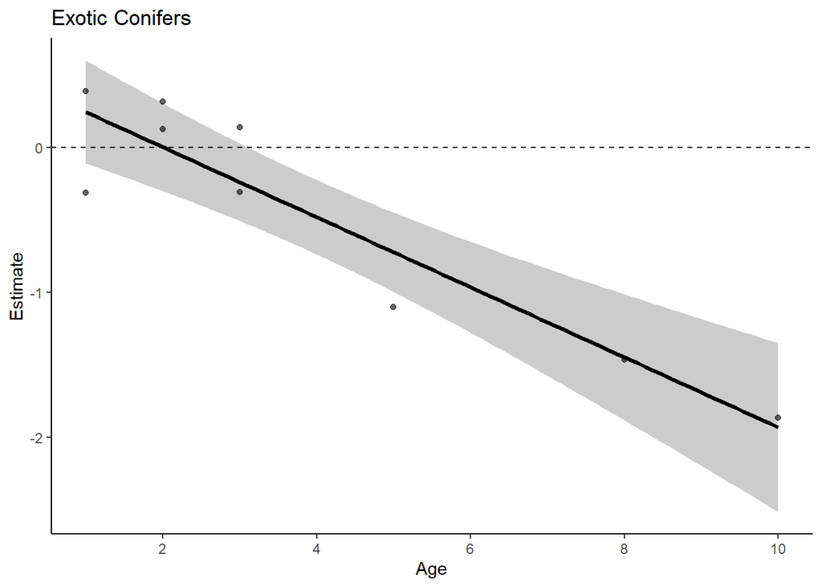

```r
ec_lm <- effect_plot(exotic_conifers_lm, pred = Age, plot.points = T, interval = T) +
  labs(x = "Age", y = expression(paste("Estimate"))) +
  ggtitle("Exotic Conifers") +
  scale_x_continuous(breaks = seq(0, 10, 2)) +
  geom_hline(yintercept =  0, linetype = "dashed") +
  theme_classic()

ec_lm
```

**Exotic Hardwoods**

There is a slight but non-significant negative relationship between age and the coefficient for the exotic hardwoods category.

```r
exotic_hardwoods_lm <- lm(estimate ~ Age, data = coefficients, subset = (term =="habsFExotic Hardwoods"))
summary(exotic_hardwoods_lm)
```

```
Call:
lm(formula = estimate ~ Age, data = coefficients, subset = (term ==
    "habsFExotic Hardwoods"))

Residuals:
     Min       1Q   Median       3Q      Max
-1.04081 -0.07321  0.02272  0.37118  0.43608

Coefficients:
            Estimate Std. Error t value Pr(>|t|)
(Intercept)  -0.2019     0.3144  -0.642    0.545
Age          -0.1438     0.0822  -1.750    0.131

Residual standard error: 0.5125 on 6 degrees of freedom
Multiple R-squared:  0.3379,    Adjusted R-squared:  0.2275
F-statistic: 3.062 on 1 and 6 DF,  p-value: 0.1307
```

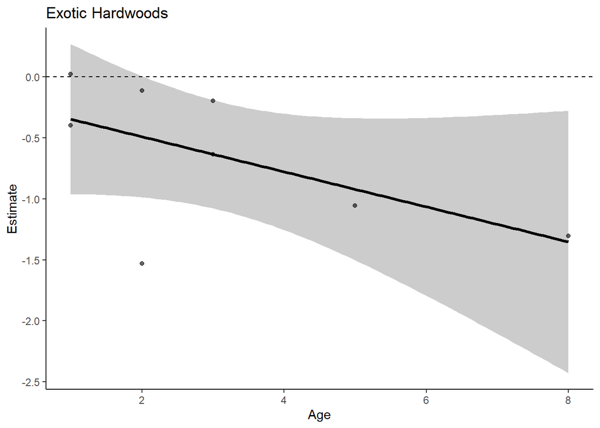

```r
eh_lm <- effect_plot(exotic_hardwoods_lm, pred = Age, plot.points = T, interval = T) +
  labs(x = "Age", y = expression(paste("Estimate"))) +
  ggtitle("Exotic Hardwoods") +
  geom_hline(yintercept =  0, linetype = "dashed") +
  theme_classic()

eh_lm
```

**Agriculture**

THe selection of agriculture does not show any clear trend relating to age.

```r
agriculture <- lm(estimate ~ Age, data = coefficients, subset = (term =="habsFAgriculture"))
summary(agriculture)
```

```
Call:
lm(formula = estimate ~ Age, data = coefficients, subset = (term ==
    "habsFAgriculture"))

Residuals:
    Min      1Q  Median      3Q     Max
-1.4693 -0.3775  0.1353  0.5002  0.9892

Coefficients:
            Estimate Std. Error t value Pr(>|t|)
(Intercept) -1.03206    0.40532  -2.546   0.0344 *
Age         -0.05337    0.07199  -0.741   0.4797
---
Signif. codes:  0 '***' 0.001 '**' 0.01 '*' 0.05 '.' 0.1 ' ' 1

Residual standard error: 0.7703 on 8 degrees of freedom
Multiple R-squared:  0.06429,   Adjusted R-squared:  -0.05267
F-statistic: 0.5497 on 1 and 8 DF,  p-value: 0.4797
```

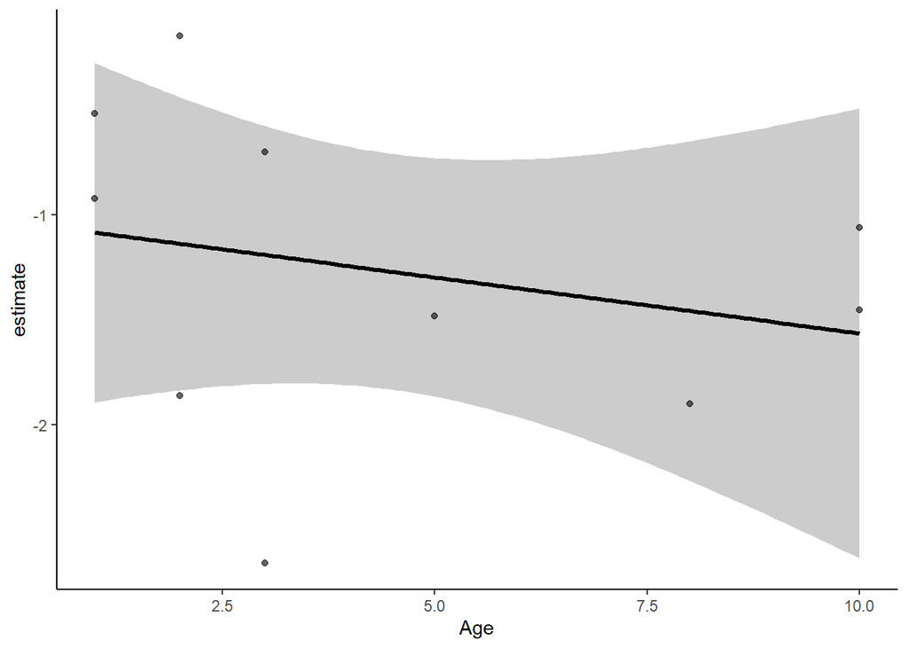

```r
effect_plot(agriculture, pred = Age, plot.points = T, interval = T) +
  theme_classic()
```

**Suburban**

As there are only two individuals that visited the suburban category enough to get a reasonable coefficient, we can’t fit a linear model.

```r
suburban <- lm(estimate ~ Age, data = coefficients, subset = (term =="habsFSuburban"))
summary(suburban)
```

```
Call:
lm(formula = estimate ~ Age, data = coefficients, subset = (term ==
    "habsFSuburban"))

Residuals:
       1        2
 0.07792 -0.07792

Coefficients: (1 not defined because of singularities)
            Estimate Std. Error t value Pr(>|t|)
(Intercept)  0.86363    0.07792   11.08   0.0573 .
Age               NA         NA      NA       NA
---
Signif. codes:  0 '***' 0.001 '**' 0.01 '*' 0.05 '.' 0.1 ' ' 1

Residual standard error: 0.1102 on 1 degrees of freedom
```

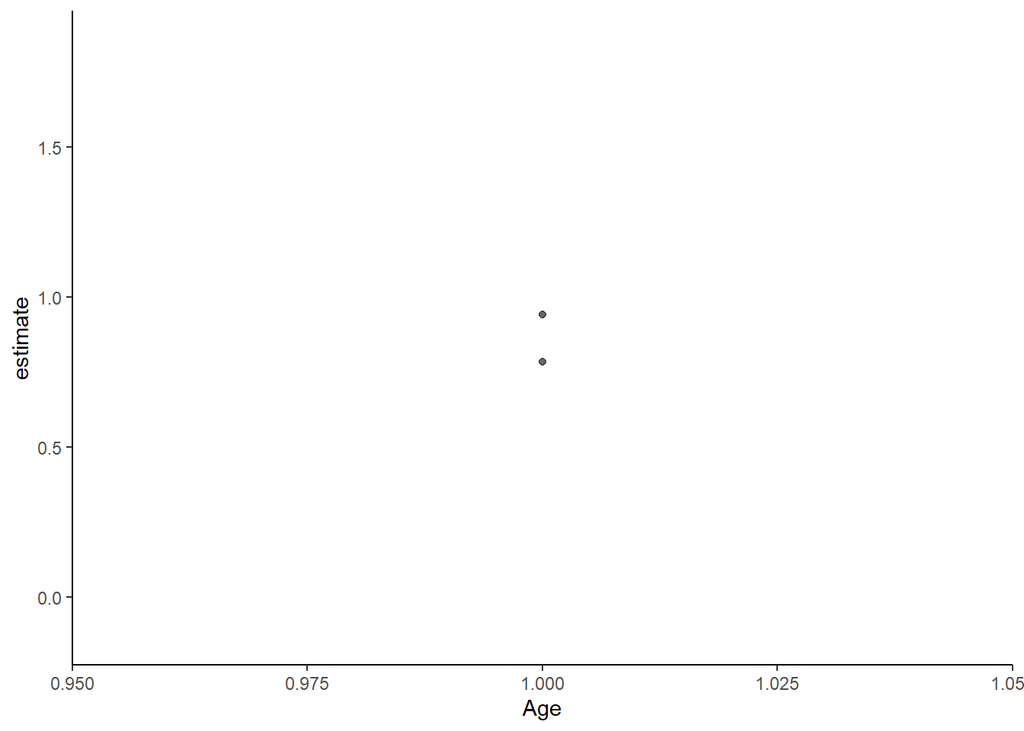

```r
effect_plot(suburban, pred = Age, plot.points = T, interval = T) +
  theme_classic()
```

**Other**

The selection of ‘other’ does not show any clear trend relating to age.

```r
other <- lm(estimate ~ Age, data = coefficients, subset = (term =="habsFOther"))
summary(other)
```

```
Call:
lm(formula = estimate ~ Age, data = coefficients, subset = (term ==
    "habsFOther"))

Residuals:
     Min       1Q   Median       3Q      Max
-0.55793 -0.13383 -0.02399  0.10665  0.60105

Coefficients:
             Estimate Std. Error t value Pr(>|t|)
(Intercept) -2.121163   0.204278 -10.384 4.67e-05 ***
Age         -0.007883   0.046711  -0.169    0.872
---
Signif. codes:  0 '***' 0.001 '**' 0.01 '*' 0.05 '.' 0.1 ' ' 1

Residual standard error: 0.3674 on 6 degrees of freedom
Multiple R-squared:  0.004724,  Adjusted R-squared:  -0.1612
F-statistic: 0.02848 on 1 and 6 DF,  p-value: 0.8715
```

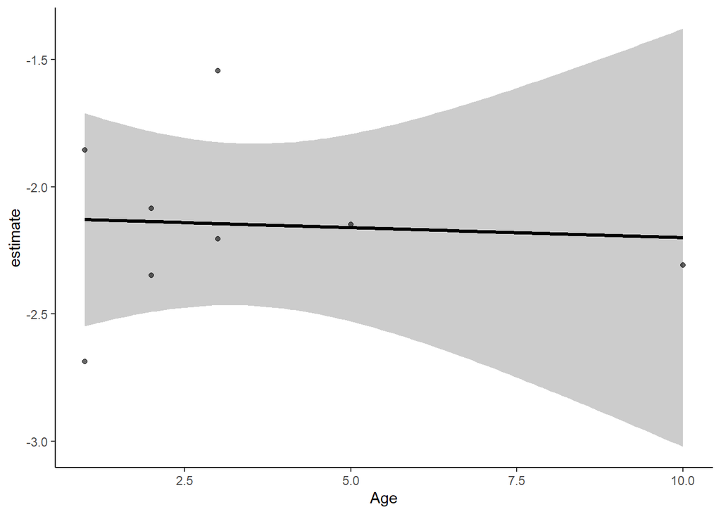

```r
effect_plot(other, pred = Age, plot.points = T, interval = T) +
  theme_classic()
```

## Combine the plots of native forest and exotic conifers

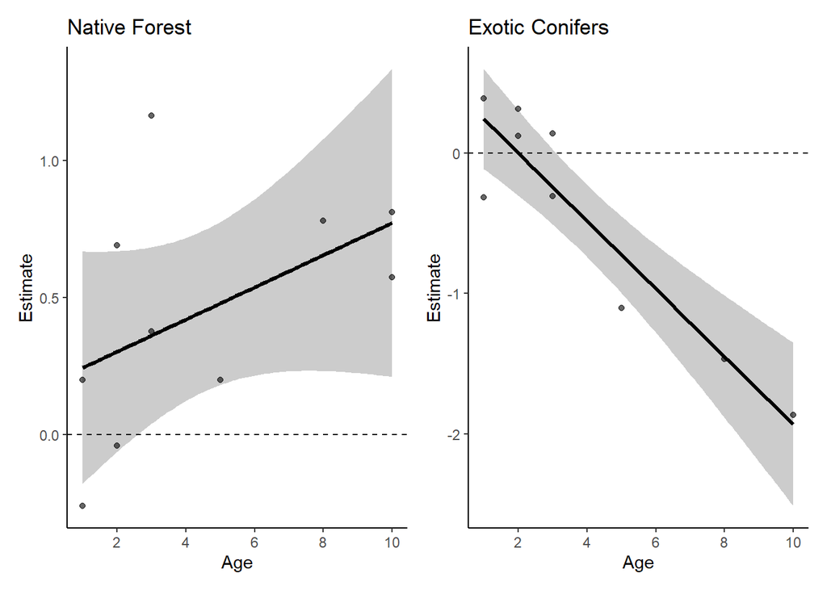

```r
nf_lm + ec_lm
```

```r
# to save the plot
# ggsave(paste0("outputs/plots/linear_models_forest_conifers", Sys.Date(), ".png"), width=180, height=80, units="mm", dpi = 800)
```

### References

Fieberg, John, Johannes Signer, Brian Smith, and Tal Avgar. 2021. “A ’How to’ Guide for Interpreting Parameters in Habitat-Selection Analyses.” *The Journal of Animal Ecology* 90 (5): 1027–43. https://doi.org/10.1111/1365-2656.13441.